# Model Explanation

This document explains and assesses a forecasting algorithm which tries to predict various US Domestic Beef prices. It models predictable, intra year trends in the industry such as Brazil's export quota and local 'Grill Season'. Put simply, the model expects beef prices to rise at the beginning of each year, peak around May then contract. This forecasting method is on par with commonly used market price oracles in terms of prediction accuracy.

# Backtesting

The following table provides estimates for how wrong these forecasts usually are (or their 'average absolute arror') in % of the product's price. They were obtained by backtesting the model on every month of data since 2003 and averaging the resulting prediction miscalculation for each product at each range.

| Forecast Distance | 90Cl | 85Cl | 65Cl | 50Cl | USDA 5-Day Roll Cutout, 100% Lean, Flats and Eyes | UB Cap & Wedge Meat (Spec Trim) CH, SE or NR-(TL) | USDA 5-Day Roll Cutout, 100% Lean Ins Rnd | USDA 5-Day Roll Cutout,100% Lean, S.P.B. | USDA 168 3 Rnd, Top Ins Rnd Se |
| --- | --- | --- | --- | --- | --- | --- | --- | --- | --- |
| 1 month ahead error (%) | 1.9 | 2.0 | 4.5 | 8.0 | 1.0 | 1.3 | 1.8 | 1.1 | 2.1 |
| 3 month ahead error (%) | 5.0 | 5.6 | 12.7 | 19.4 | 4.6 | 8.6 | 6.6 | 5.1 | 9.1 |
| 6 month ahead error (%) | 8.0 | 9.0 | 18.9 | 26.3 | 9.0 | 12.0 | 10.7 | 9.8 | 11.5 |
| 12 month ahead error (%) | 12.2 | 13.4 | 22.9 | 32.8 | 14.4 | 16.0 | 14.1 | 14.7 | 13.9 |
| 18 month ahead error (%) | 14.1 | 15.5 | 23.4 | 35.9 | 17.6 | 17.7 | 16.8 | 17.7 | 14.8 |

# Steiner/Sterling Testing

The following section shows how the model would have performed if it was applied in previous years. It compares these performances with that of widely used beef price oracles Steiner and Sterling. To measure the accuracy of each model, the price difference between historical predictions and actual prices are taken at each month. For example, the first graph shown below imagines that our forecasting model was applied at the start of January 2022 looking forwards. For each month of 2022, it subtracts the actual price that occured and the predicted price. Next, all of these price differences are averaged to get an overall forecast error (given as a percentage of actual price) for each forecaster. The graphs are grouped by time period and an overall summary of each forecasters' performance is provided at the end. 90s backtested forecasts are given seperately due to their special interest.

# Sterling Comparison Jan 2022

```
S Error: 12.8%
Our Error: 13.6%
```

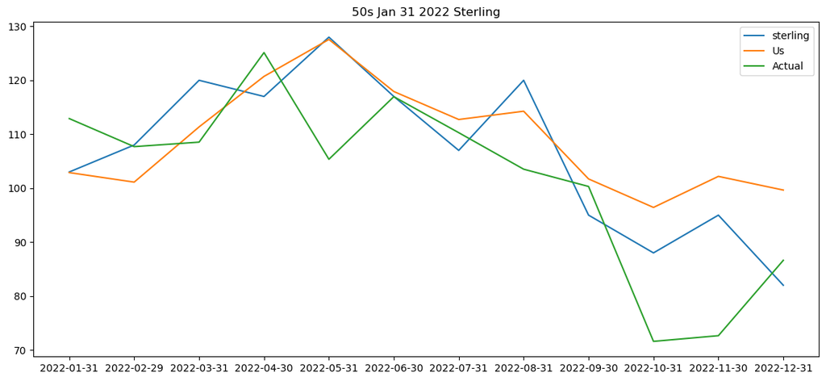

```
S Error: 15.3%
Our Error: 34.8%
```

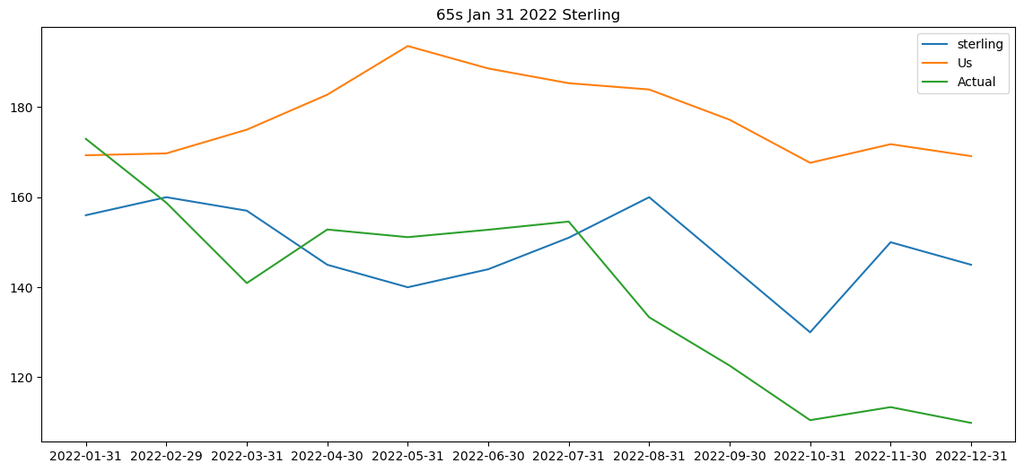

```
S Error: 9.5%
Our Error: 15.7%
```

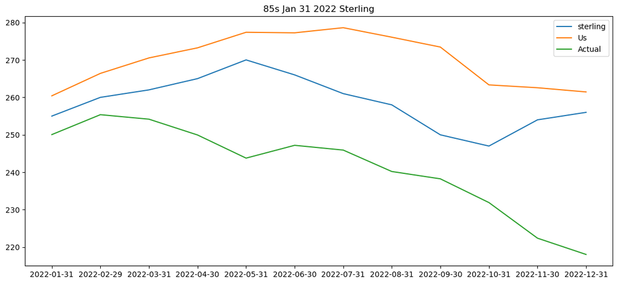

```
S Error: 37.3%
Our Error: 45.8%
```

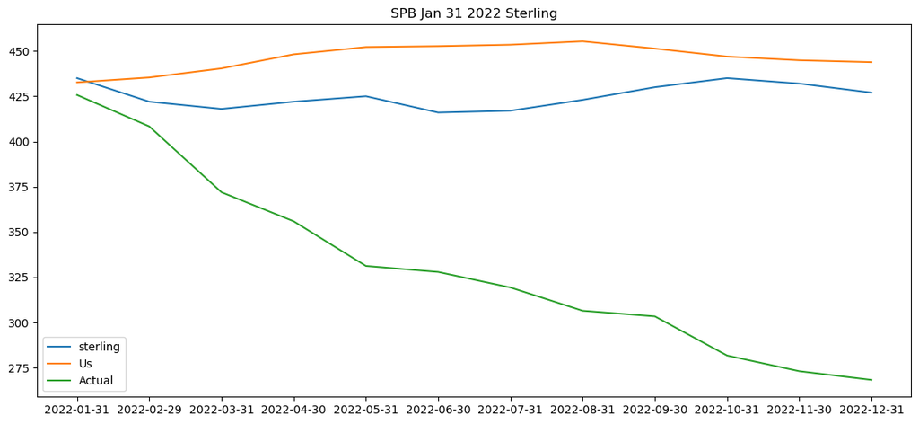

# Sterling Jan 2017

```
S Error: 45.1%
Our Error: 46.8%
```

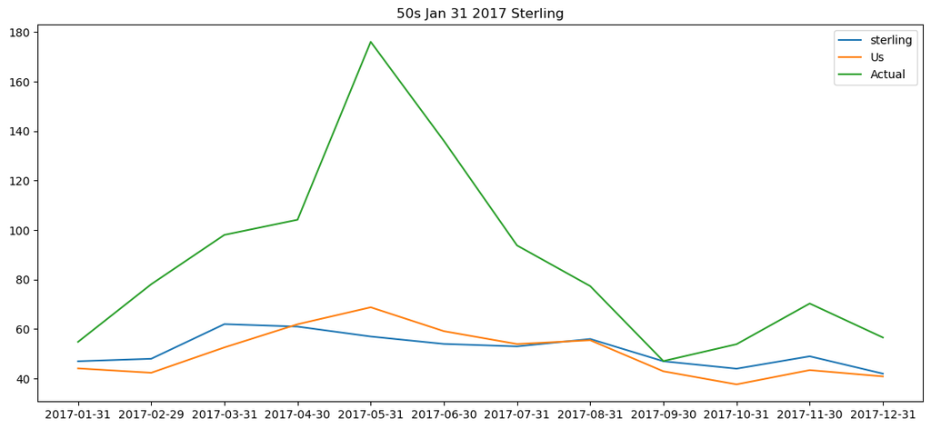

```
S Error: 24.0%
Our Error: 17.8%
```

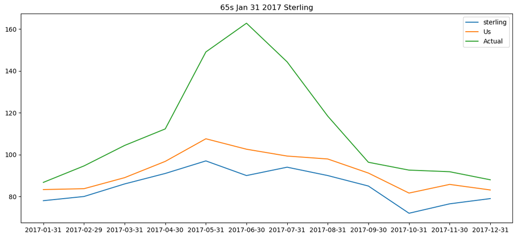

```
S Error: 10.3%
Our Error: 1.3%
```

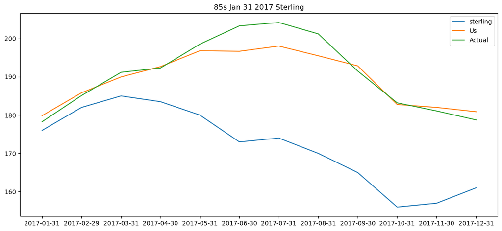

```
S Error: 5.8%
Our Error: 5.1%
```

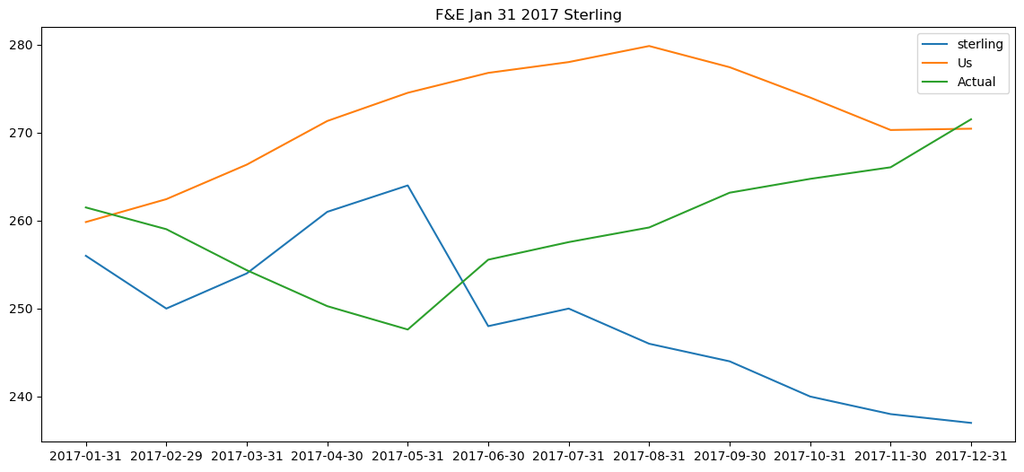

```
S Error: 4.3%
Our Error: 6.1%
```

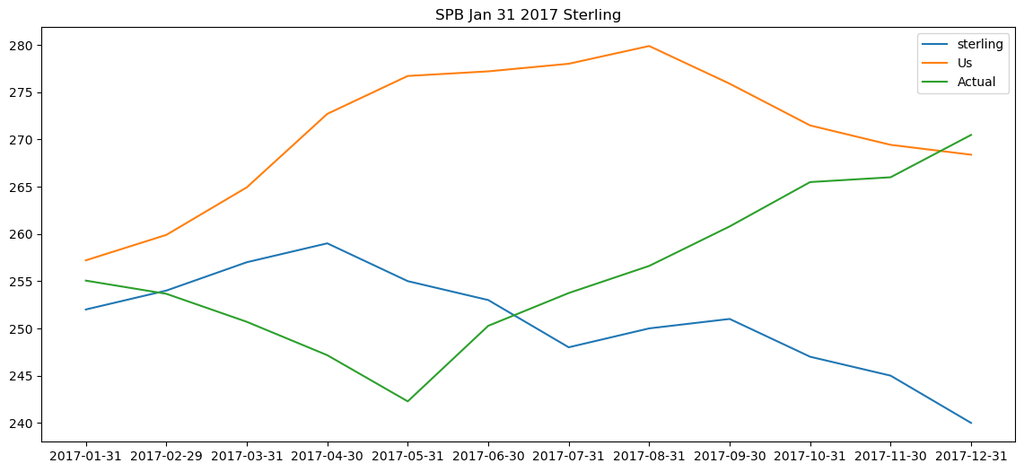

# Steiner Feb 2018

```
S Error: 15.0%
Our Error: 17.7%
```

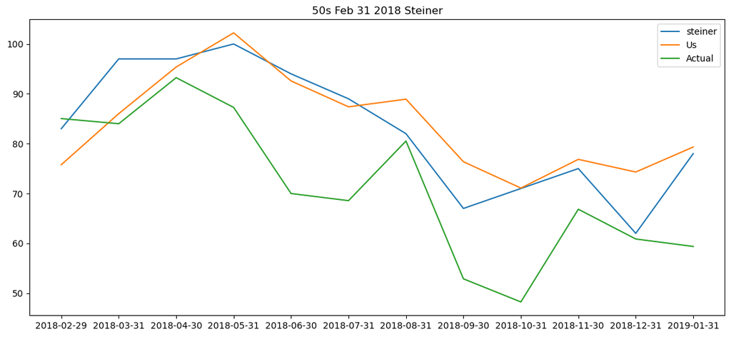

```
S Error: 7.7%
Our Error: 8.6%
```

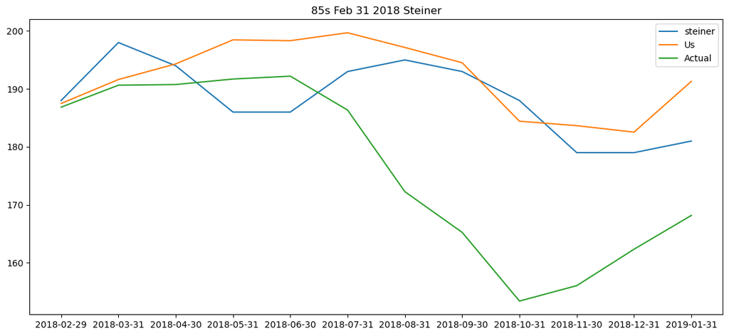

```
S Error: 4.0%
Our Error: 2.9%
```

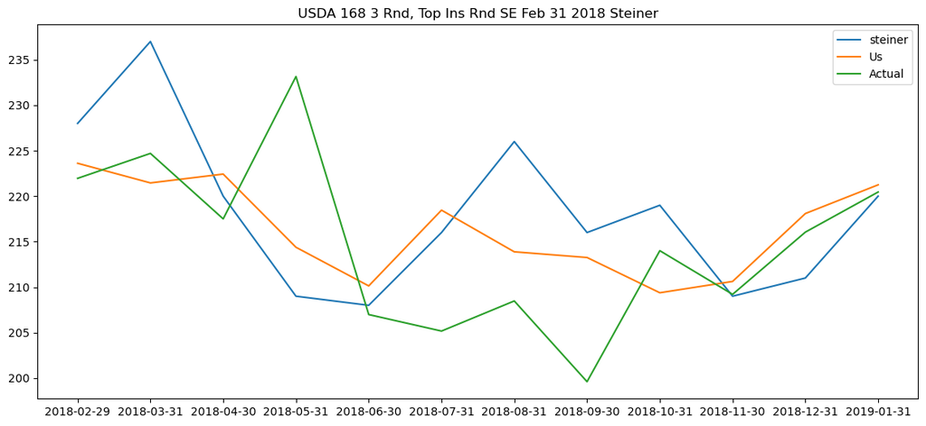

# Steiner Feb 2022

```
S Error: 17.9%
Our Error: 22.6%
```

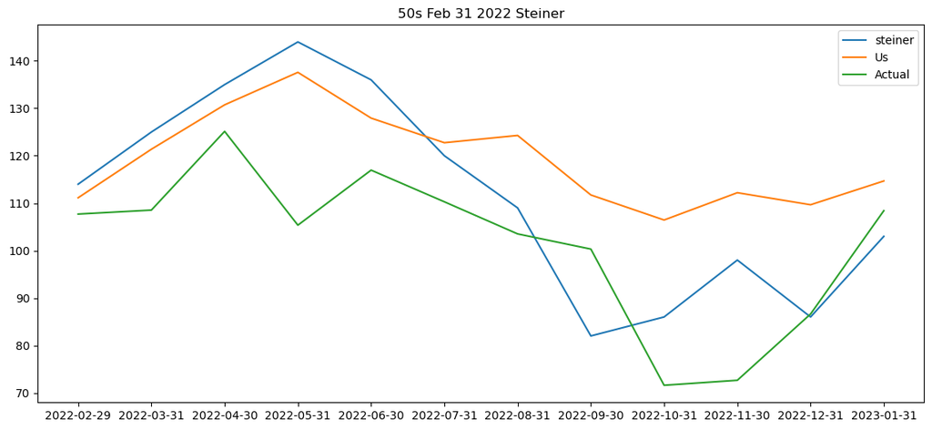

```
S Error: 15.6%
Our Error: 11.7%
```

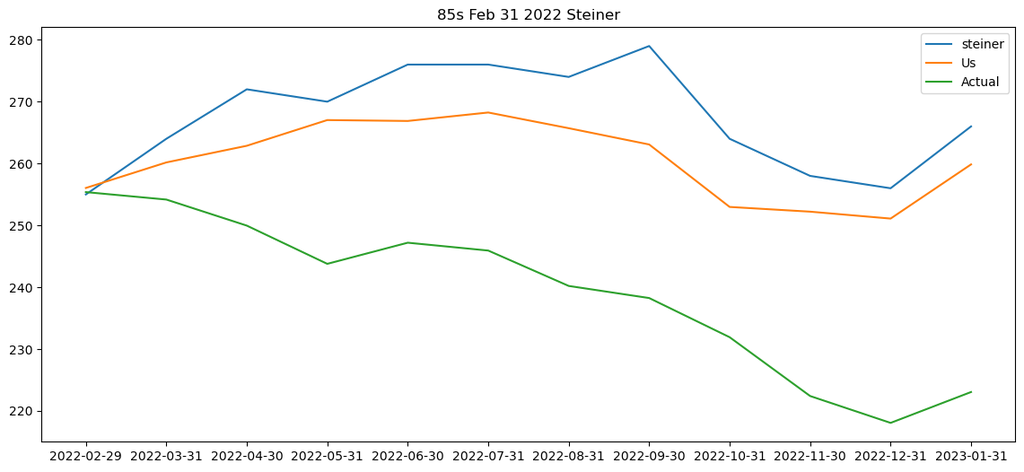

```
S Error: 15.5%
Our Error: 15.3%
```

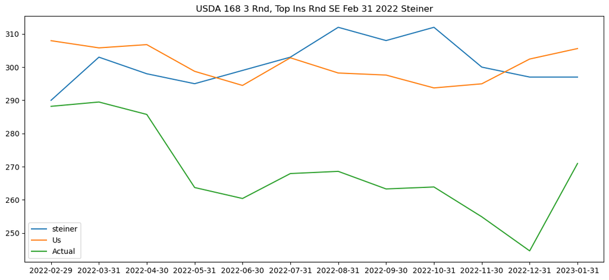

```
S Error: 65.7%
Our Error: 48.0%
```

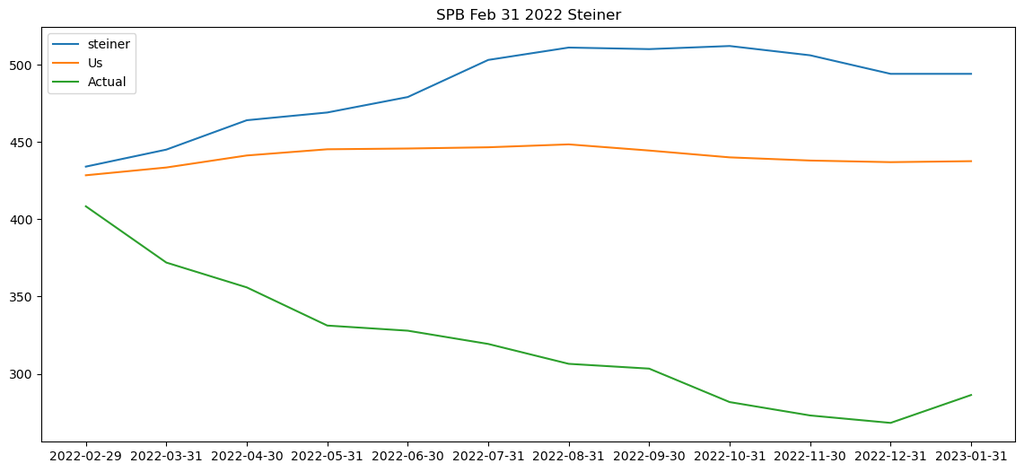

# Results For Non-90Cl Products

```
Sterling Avg. Error: 18.3%
Steiner Avg. Error: 20.2%
Our Avg. Error: 19.6%
```

# Steiner/Sterling Testing 90s

```
Steiner Error: 23.231916666666667
Sterling Error: 9.893583333333341
Our Error: 19.958018650793637
```

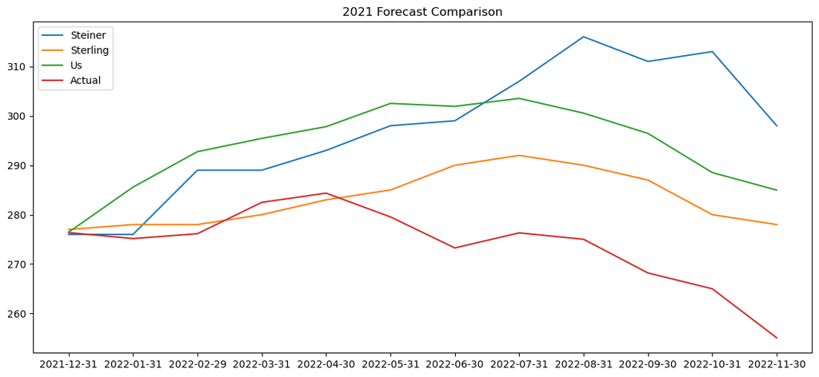

```
Steiner Error: 9.462666666666664
Sterling Error: 15.626833333333332
Our Error: 13.472348809523796
```

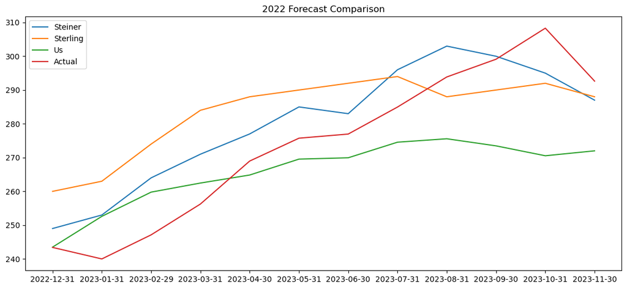

```
Steiner Error: 5.196375000000006
Our Error: 7.086763095238105
```

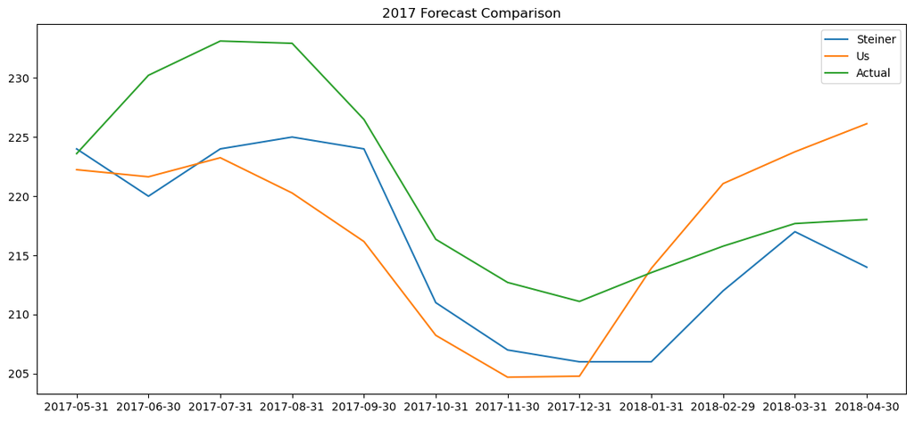

```
Steiner Error: 12.91420833333333
Our Error: 9.476175595238127
```

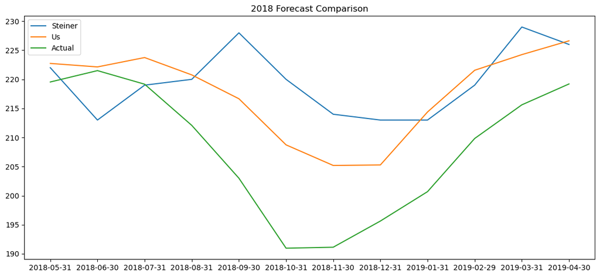

# Results For 90s Forecasts

[output not shown]